# Métodos Computacionais para Análise de Risco

24 de março de 2023

## Aula de Hoje

- Gráficos Avançados
  - `ggplot2`
- Algumas recomendações para como inserir gráficos com o `markdown`

## Gráficos no R - Básico

[figure not shown]

## Gráficos no R - Avançado

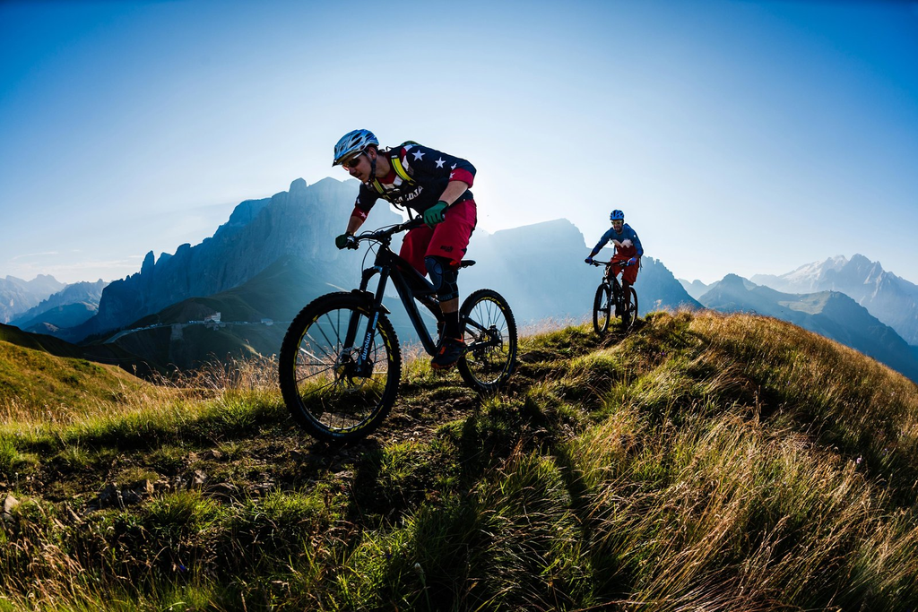

## ggplot2

- `ggplot2` é um pacote para criar gráficos de maneira declarativa baseada no livro *The Grammar of Graphics* de Leland Wilkinson.
- Você fornece os dados, informa como mapear as variáveis esteticamente, qual função primitiva usar, e o pacote cuida do resto.
- O pacote [`ggplot2`](http://ggplot2.tidyverse.org) é parte da coleção de pacotes [`tidyverse`](https://www.tidyverse.org/packages/) para **Ciência de Dados**.
- Você pode instalar todos os pacotes usando `install.packages("tidyverse")`, ou apenas `install.packages("ggplot2")`.

## ggplot2

- O jeito de usar o `ggplot2` utiliza uma filosofia diferente de visualização.
- Na maioria das vezes:
  1. vamos começar com `ggplot()`;
  2. depois fornecer os dados e o “mapeamento estético” (*aesthetic mapping*) com o comando `aes()`;
  3. podemos adicionar camadas (com `geom_point()` ou `geom_histogram()`), alterar escalas (com `scale_colour_brewer()`), lapidar (com `facet_wrap()`), sistema de coordenadas (com `coord_flip()`)…

## ggplot2

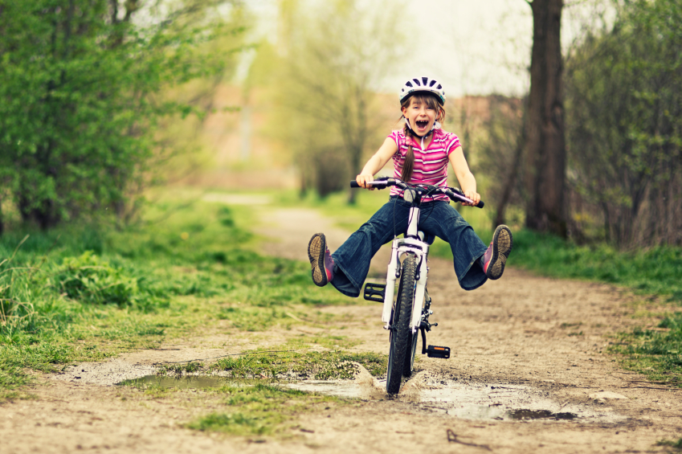

## Learning ggplot2

- Recomendações do próprio [site do ggplot](http://ggplot2.tidyverse.org/#learning-ggplot2):
  - “If you are new to ggplot2 you are better off starting with a systematic introduction, rather than trying to learn from reading individual documentation pages. Currently, there are three good places to start:
  - The [data visualisation](http://r4ds.had.co.nz/data-visualisation.html) and [graphics for communication](http://r4ds.had.co.nz/graphics-for-communication.html) chapters in [R for data science](http://r4ds.had.co.nz). (…)”

## Learning ggplot2

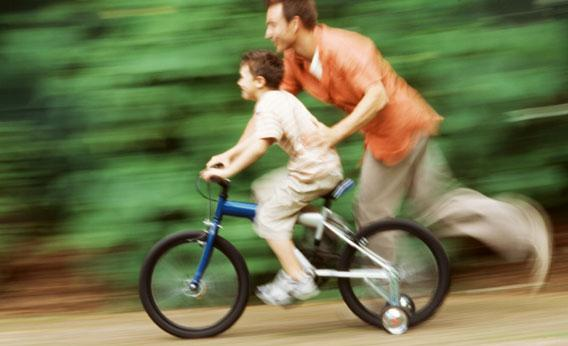

## ggplot2

- Para começar a usar o pacote:

```r
require(ggplot2)
```

- A estrutura dos códigos pode ser resumida em

```
ggplot(data = [dataset], aes(x = [x-variable], y = [y-variable])) +
   geom_xxx() +
   other options
```

- `geom_xxx()` determina o tipo de gráfico que você irá produzir.

## Exemplo - mpg

- **Dados:** `mpg` - dados de gasto de combustível para diferentes modelos de carro (carregado com o pacote `ggplot2`)
  - algumas variáveis: `displ` (cilindrada em litros), `hwy` (consumo em milhas por galão)
  - descrição: `?mpg`

## Exemplo - mpg

- Vamos fazer um *scatterplot* com a variável `displ` no eixo x, e `hwy` no eixo y:

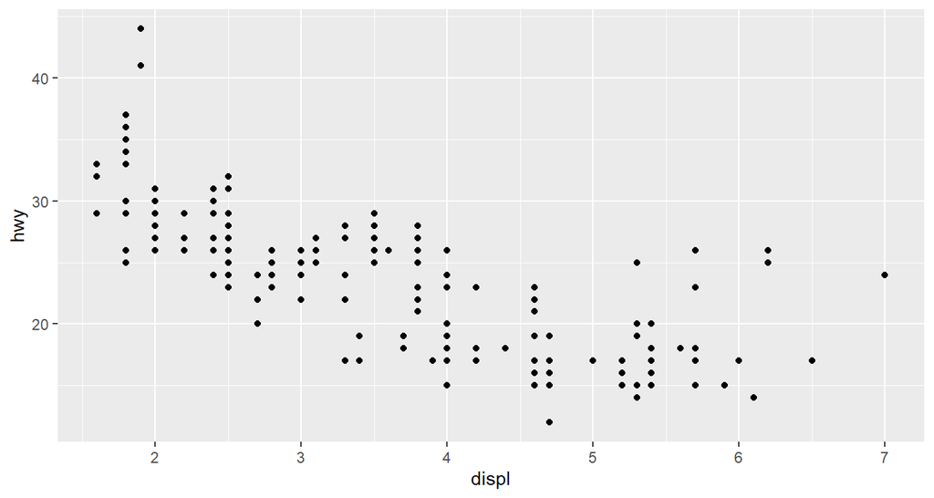

```r
ggplot(data = mpg) +
  geom_point(mapping = aes(x = displ, y = hwy))
```

## Exemplo - mpg

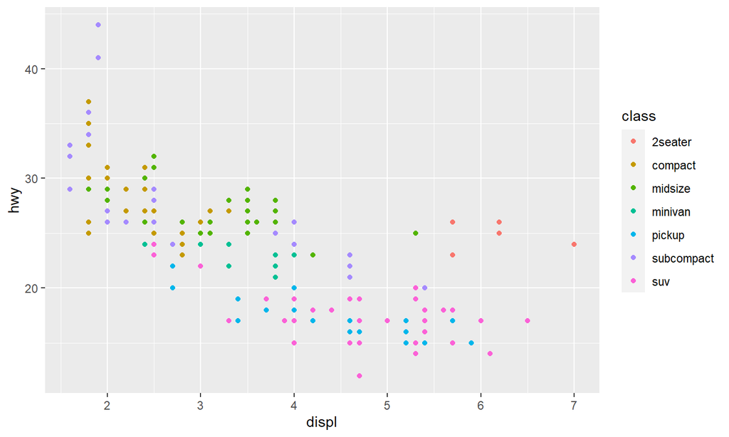

```r
ggplot(data = mpg) +
  geom_point(mapping = aes(x = displ, y = hwy, color = class))
```

## Exemplo - mpg

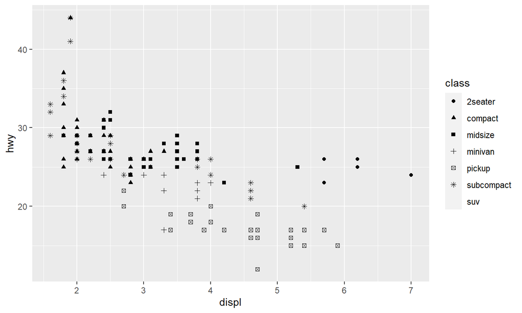

```r
ggplot(data = mpg) +
  geom_point(mapping = aes(x = displ, y = hwy, shape = class))
```

## Exemplo - mpg

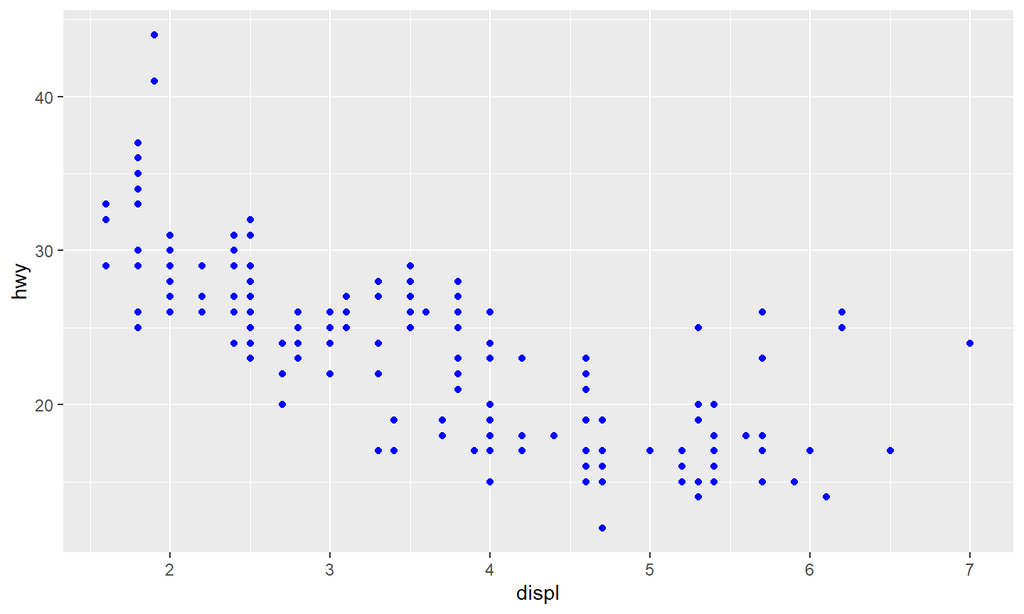

```r
ggplot(data = mpg) +
  geom_point(mapping = aes(x = displ, y = hwy), color = "blue")
```

## Ótimo material extra

- Slides da aula de [Visualização de Dados](http://www2.stat.duke.edu/courses/Fall17/sta112.01/slides/03-deck.html) da disciplina de [*Data Science*](http://www2.stat.duke.edu/courses/Fall17/sta112.01/) oferecida por Mine Çetinkaya-Rundel para graduação na Duke University.

## Exemplo - Starwars

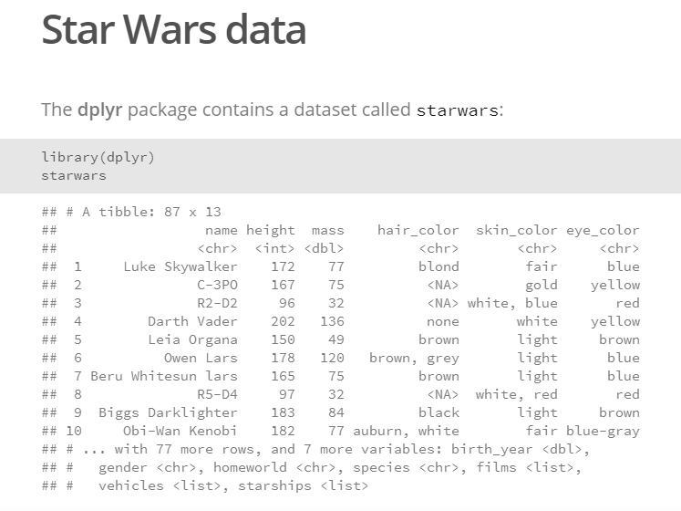

## Exemplo - Starwars

[figure not shown]

## Exemplo - Starwars

- [*Scatterplots*](http://www2.stat.duke.edu/courses/Fall17/sta112.01/slides/03-deck.html#15)
- Variáveis adicionais:
  - *aesthetics*: formato, cor, tamanho

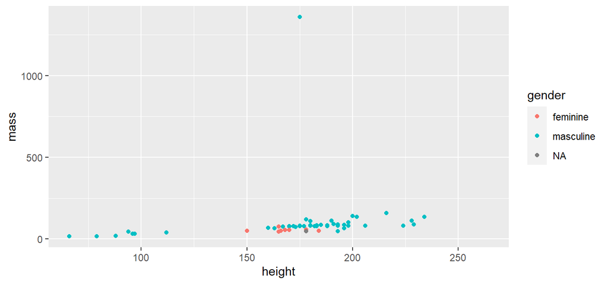

## Exemplo - Starwars

- *faceting*: gráficos menores com *subsets* dos dados de acordo com uma categoria

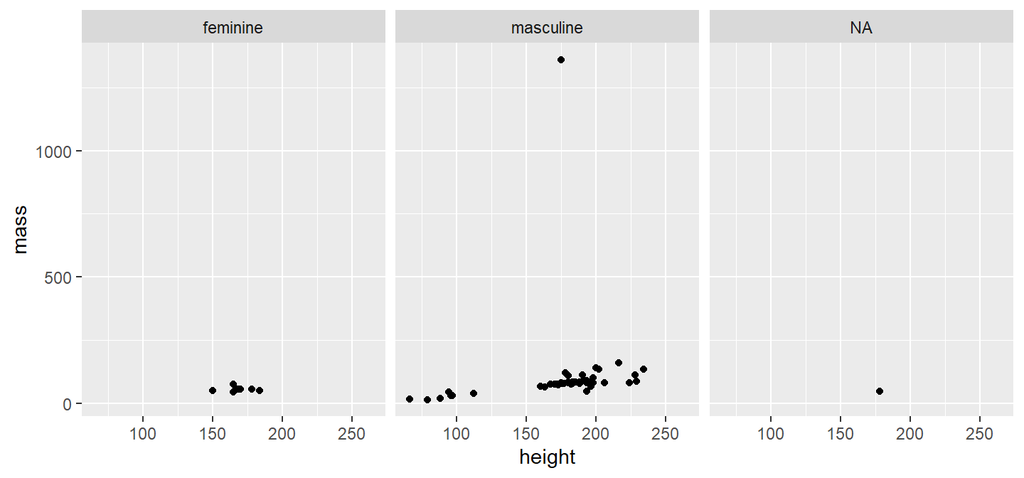

## Exemplo - Starwars

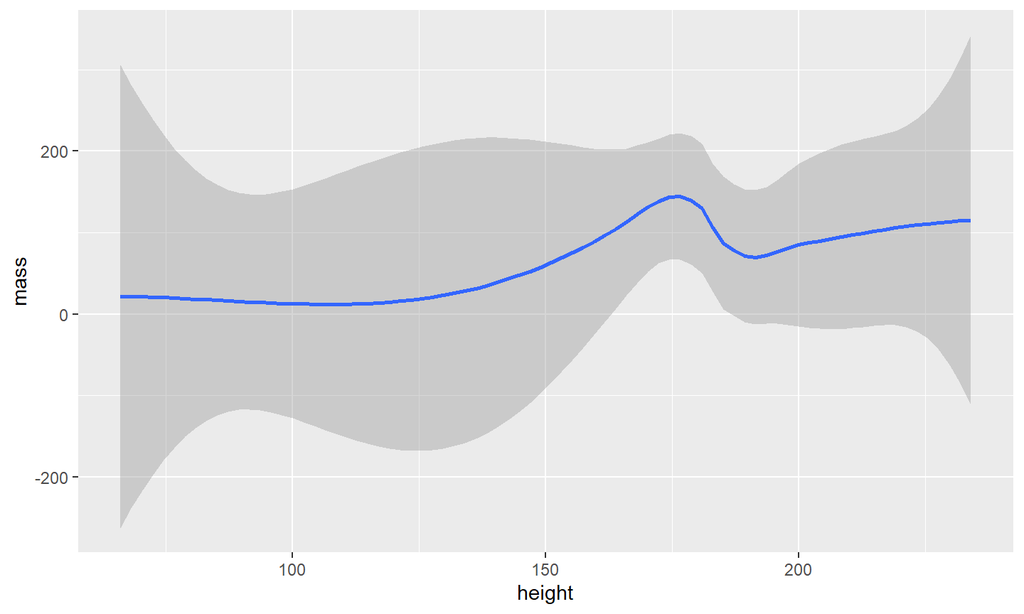

## Exemplo - Starwars

- [Histograma](http://www2.stat.duke.edu/courses/Fall17/sta112.01/slides/03-deck.html#39)

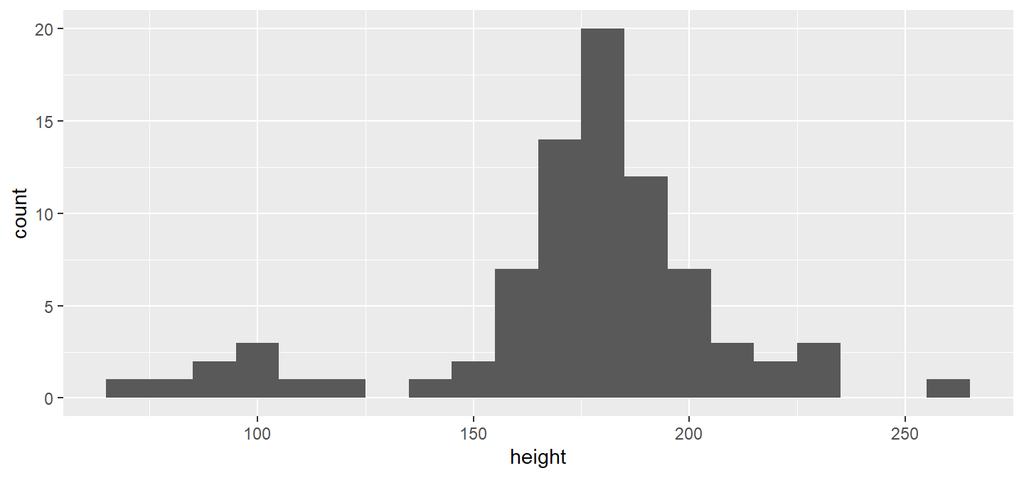

## Exemplo - Starwars

- [Gráfico de barra](http://www2.stat.duke.edu/courses/Fall17/sta112.01/slides/03-deck.html#40)

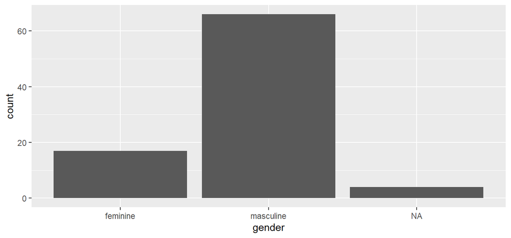

## Mais materiais

- [Data visualization with ggplot2 Cheat Sheet](https://raw.githubusercontent.com/rstudio/cheatsheets/main/data-visualization.pdf)
- [ggplot2 tutorial by Jenny Bryan](https://github.com/jennybc/ggplot2-tutorial)
- More by Jenny Bryan (University of British Columbia):
  - https://stat545.com/ (Seção *All the graph things*)
  - http://stat545.com/block015_graph-dos-donts.html (Muito interessante!)
  - http://shiny.stat.ubc.ca/r-graph-catalog/ (Catálogo com vários exemplos de gráficos feitos no R)

## Mais materiais

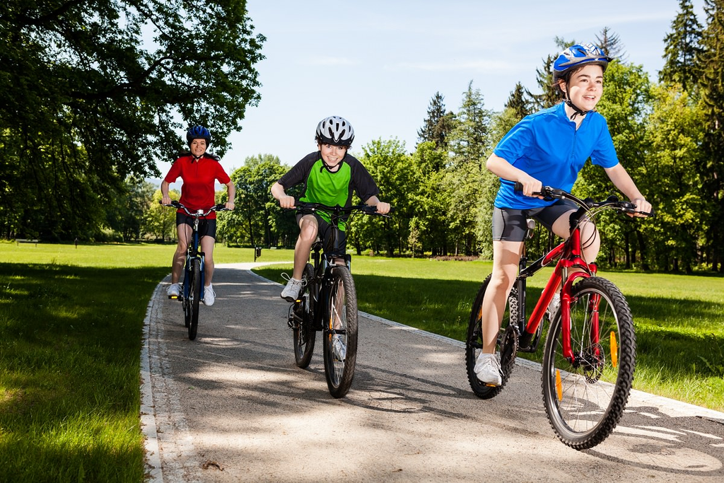